# Google Data Analytics Capstone: Cyclistic

## **10.7i Comparing Member Ride Duration to Casual Ride Duration (PM Peak Season)**

#### While casual riders take their longest rides of the PM commute period from 4pm to 4:59pm on both classic and electric bikes, this period marks the shortest rides for member riders on both classic and electric bikes.

#### Starting at 5pm, peak season member bike rides become significantly longer than their annual averages. Member electric rides become 7.32% to 7.85% longer from 5pm to 7:79pm, while member classic rides become 8.49% to 12.00% longer than annual averages for the same time periods.

#### These longer-than-average PM rides might indicate that members are either riding bikes door-to-door, instead of as part of a multimodal transportation plan, or that they are enjoying recreational rides during Chicago’s best riding weather.

## **10.7j Interpreting Member/Casual Ride Durations During AM/PM Commute Periods**

#### Based on the above analysis and our study of start times during peak season (10.6d), we can deduce that the most notable change in trip duration occurs with casual riders on electric or casual bikes from 7:00am to 8:59am, where rides are significantly shorter than annual averages for the same cohorts of riders.

#### During the PM commute window, we see casual riders taking slightly longer trips when using electric bikes, while classic rides remain close to the annual average.

#### Members appear to take more advantage of the nicer weather and appear to take longer evening rides, either recreationally or as door-to-door commute trips home.

## **10.8 Station-To-Station Analysis**

#### At this point in our analysis, we have compared and contrasted casual and member behavior based on when they use the Cyclistic system, rider preferences between electric and classic bikes, and seen how time, weather, day, and bike type impact ride duration.

#### In our final stage of analysis, we will use station-to-station data in order to answer any remaining questions on customer behavior and better target Cyclistic’s digital marketing campaign to achieve their business task.

#### For this analysis, we will use the ‘trips_w_stations’ dataframe we created during data transformation. This dataframe includes all cleaned records that contained complete station name and GPS data for both start and end stations, and accounts for 77% of all trips used for analysis.

#### This geographic analysis will highlight four key periods of time: Peak-season weekends, Thursday pm commutes, Friday am commutes, and Friday pm commutes. Additionally, we will incorporate a detailed look at casual rider behavior during AM commutes to better understand why casual trip durations spike after 9am.

## **10.8a Peak Season Weekends**

#### Filtering for peak season weekends

```r
stations_peak_weekend <- trips_w_stations %>%
  filter(workday_weekend == 'weekend') %>%
  filter(week >= 24 & week <= 27)

stations_peak_we_cas <- stations_peak_weekend %>%
  filter(customer_type == 'casual')

stations_peak_we_mem <- stations_peak_weekend %>%
  filter(customer_type == 'member')
```

```r
## Weekend member start station
stat_we_mem_grouped_start <- stations_peak_we_mem %>%
  group_by(start_station_name) %>%
  summarize(ride_count = n(), start_lng, start_lat,
            mean_trip_duration = mean(trip_length)) %>%
  arrange(desc(ride_count)) %>%
  distinct(start_station_name, .keep_all = TRUE)

## Weekend member end station
stat_we_mem_grouped_end <- stations_peak_we_mem %>%
  group_by(end_station_name) %>%
  summarize(ride_count = n(), end_lng, end_lat,
            mean_trip_duration = mean(trip_length)) %>%
  arrange(desc(ride_count)) %>%
  distinct(end_station_name, .keep_all = TRUE)

## Weekend casual start station for viz
stat_we_cas_grouped_start <- stations_peak_we_cas %>%
  group_by(start_station_name) %>%
  summarize(ride_count = n(), start_lng, start_lat,
            mean_trip_duration = mean(trip_length)) %>%
  arrange(desc(ride_count)) %>%
  distinct(start_station_name, .keep_all = TRUE)

## Weekend casual end station for viz
stat_we_cas_grouped_end <- stations_peak_we_cas %>%
  group_by(end_station_name) %>%
  summarize(ride_count = n(), end_lng, end_lat,
            mean_trip_duration = mean(trip_length)) %>%
  arrange(desc(ride_count)) %>%
  distinct(end_station_name, .keep_all = TRUE)
```

## **Visualizing peak season weekend activity**

[figure not shown]

```r
viz_peak_we_stations <-
  mapview(stat_we_mem_grouped_start[1:50, ],
          xcol = 'start_lng',
          ycol = 'start_lat',
          cex = 'ride_count',
          alpha = 0.5,
          grid = F,
          crs = 4269,
          legend = T,
          layer.name = 'Top 50 member start stations',
          zcol = 'ride_count',
          col.regions = brewer.pal(n = 8, name = 'Greens')
  )+
  mapview(stat_we_mem_grouped_end[1:50, ],
          xcol = 'end_lng',
          ycol = 'end_lat',
          cex = 'ride_count',
          alpha = 0.5,
          grid = F,
          crs = 4269,
          legend = T,
          layer.name = 'Top 50 member end stations',
          zcol = 'ride_count',
          col.regions = brewer.pal(n = 8, name = 'Reds')
  ) +
  mapview(stat_we_cas_grouped_start[1:50, ],
          xcol = 'start_lng',
          ycol = 'start_lat',
          cex = 'ride_count',
          alpha = 0.5,
          grid = F,
          crs = 4269,
          legend = T,
          col.regions = brewer.pal(n = 8, name = 'Blues'),
          layer.name = 'Top 50 casual start stations',
          zcol = 'ride_count'
  ) +
  mapview(stat_we_cas_grouped_end[1:50, ],
          xcol = 'end_lng',
          ycol = 'end_lat',
          cex = 'ride_count',
          alpha = 0.5,
          grid = F,
          crs = 4269,
          legend = T,
          col.regions = brewer.pal(n = 8, name = 'Oranges'),
          layer.name = 'Top 50 casual end stations',
          zcol = 'ride_count'
  )
```

## **10.8a Peak Season Weekend Analysis**

#### The above visualization shows the top 50 start and end stations for member and casual riders during peak season weekends.

## **Lake Side Popularity**

#### Based on our visualization, casual riders tend to start and end their rides at the city’s easternmost stations and remain there, taking advantage of bike paths along the waterfront and Magnificent Mile neighborhoods. Casual rides cluster tightly along the coast, with only three end stations on the west side of the Chicago River, two of which are located next to large public parks (Wicker Park and Logan Square), and the third positioned at a major traffic intersection (West Division and Milwaukee Ave).

#### Of note are the top 5 casual customer start/end stations, Streeter Dr & Grand Ave, DuSable Lake Shore Dr & Monroe St, Michigan Ave & Oak St, DuSable Lake Shore Dr & North Blvd, and Theater on the Lake.

#### A review of weekend member activity shows a similar preference for lakeside riding, however we see the Magnificent Mile neighborhood is far less popular with member riders. Additionally, we see five of the top 50 member end stations are west of the Chicago River.

## **Start/End Clustering**

#### Unlike other time periods under review, we see very little geographic spread in start/end station activity during the weekend. Regardless of customer type, almost all of the top 50 start/end stations appear to cluster along the shoreline and between the Near North Side, Lakeview, and Lincoln Park neighborhoods

## **Interpretation**

#### Overall, weekend activity seems to match our expectations - largely recreational riding from both casual and member riders along the shore.

#### It is notable that stations within the Loop, Chicago’s primary office/business district, are absent from any top 50 categories.

#### Weekends reveal three popular traffic corridors, particularly among casual riders: South/North Michigan Avenue, North Wells Street, and North Clark Street.

## **10.8b Peak Season Thursday PM (4pm to 7:59pm)**

```r
stations_peak_thursday_pm <- trips_w_stations %>%
  filter(weekday == "Thursday") %>%
  filter(week >= 24 & week <= 27) %>%
  filter(start_hour >= 16 & start_hour <= 19)

stations_peak_thursday_pm_cas <- stations_peak_thursday_pm %>%
  filter(customer_type == 'casual')

stations_peak_thursday_pm_mem <- stations_peak_thursday_pm %>%
  filter(customer_type == 'member')
```

#### Prepping for viz

```r
## Thursday pm member start station
stat_thurs_pm_mem_grouped_start <- stations_peak_thursday_pm_mem %>%
  group_by(start_station_name) %>%
  summarize(ride_count = n(), start_lng, start_lat,
            mean_trip_duration = mean(trip_length)) %>%
  arrange(desc(ride_count)) %>%
  distinct(start_station_name, .keep_all = TRUE)

## Thursday pm member end station
stat_thurs_pm_mem_grouped_end <- stations_peak_thursday_pm_mem %>%
  group_by(end_station_name) %>%
  summarize(ride_count = n(), end_lng, end_lat,
            mean_trip_duration = mean(trip_length)) %>%
  arrange(desc(ride_count)) %>%
  distinct(end_station_name, .keep_all = TRUE)

## Thursday pm casual start station for viz
stat_thurs_pm_cas_grouped_start <- stations_peak_thursday_pm_cas %>%
  group_by(start_station_name) %>%
  summarize(ride_count = n(), start_lng, start_lat,
            mean_trip_duration = mean(trip_length)) %>%
  arrange(desc(ride_count)) %>%
  distinct(start_station_name, .keep_all = TRUE)

## Thursday pm casual end station for viz
stat_thurs_pm_cas_grouped_end <- stations_peak_thursday_pm_cas %>%
  group_by(end_station_name) %>%
  summarize(ride_count = n(), end_lng, end_lat,
            mean_trip_duration = mean(trip_length)) %>%
  arrange(desc(ride_count)) %>%
  distinct(end_station_name, .keep_all = TRUE)
```

#### Visualizing peak season Thursday pm commutes

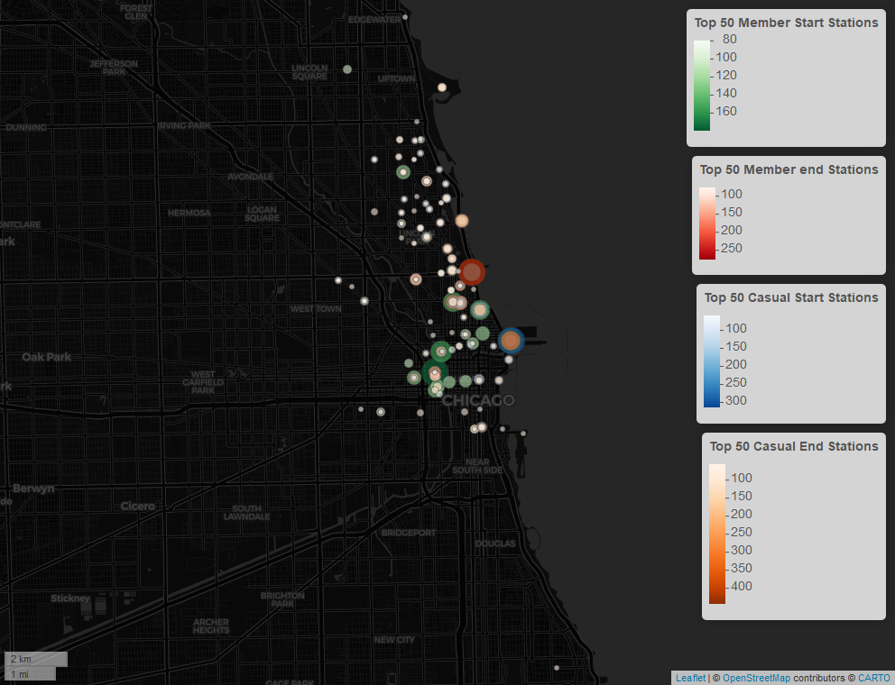

```r
viz_peak_thurs_pm <-
  mapview(stat_thurs_pm_mem_grouped_start[1:50, ],
          xcol = 'start_lng',
          ycol = 'start_lat',
          cex = 'ride_count',
          alpha = 0.5,
          grid = F,
          crs = 4269,
          legend = T,
          layer.name = 'Top 50 Member Start Stations',
          zcol = 'ride_count',
          col.regions = brewer.pal(n = 8, name = 'Greens')
  )+
  mapview(stat_thurs_pm_mem_grouped_end[1:50, ],
          xcol = 'end_lng',
          ycol = 'end_lat',
          cex = 'ride_count',
          alpha = 0.5,
          grid = F,
          crs = 4269,
          legend = T,
          layer.name = 'Top 50 Member end Stations',
          zcol = 'ride_count',
          col.regions = brewer.pal(n = 8, name = 'Reds')
  ) +
  mapview(stat_thurs_pm_cas_grouped_start[1:50, ],
          xcol = 'start_lng',
          ycol = 'start_lat',
          cex = 'ride_count',
          alpha = 0.5,
          grid = F,
          crs = 4269,
          legend = T,
          col.regions = brewer.pal(n = 8, name = 'Blues'),
          layer.name = 'Top 50 Casual Start Stations',
          zcol = 'ride_count'
  ) +
  mapview(stat_thurs_pm_cas_grouped_end[1:50, ],
          xcol = 'end_lng',
          ycol = 'end_lat',
          cex = 'ride_count',
          alpha = 0.5,
          grid = F,
          crs = 4269,
          legend = T,
          col.regions = brewer.pal(n = 8, name = 'Oranges'),
          layer.name = 'Top 50 Casual End Stations',
          zcol = 'ride_count'
  )
```

## **10.8b Peak Season Thursday PM Commutes**

## **Start Station Preferences**

#### Casual riders continue to show a preference for shoreside start and end stations, however we do see an increase in casual activity in the Near North Side neighborhood and inner-city stations west of North Wells Street.

#### Although member riders show strong presence at shoreside stations, member riders also demonstrate a much higher tendency to start rides in the Loop and Greektown neighborhoods.

## **Transit Hub/Multimodal Activity**

#### When comparing the top 50 member/casual start stations on Thursday evening rush hours, we find a critical similarity that will be key to our marketing campaign: Transit hub stations.

#### Within the top-50 start stations for member and casual riders, six are located within one block of “El” train stations. While these docks are used more heavily by member riders, they may be critical to converting casual customers into members. These stations are adjacent to the Belmont, Fullerton, North/Clybourn, Clark/Division, and Grand El stations, as well as the Ogilvie Transportation Center, which serves as a regional transit hub.

#### These Cyclistic docks are as follows: Wilton Ave & Belmont Ave, Sheffield Ave & Fullerton Ave, Halsted St & Clybourn Ave, Clark St & Elm St, Wabash Ave & Grand Ave, and Clinton St & Washington Blvd.

## **Destinations**

#### A review of member/casual end stations shows some activity from the Loop and Near North Side neighborhoods to transit hubs to the west and south, however it appears the most popular destination stations land between the Lake View and Lincoln Park neighborhoods, indicating post-work trips either home, or to nightlife locations frequently found in these recently-gentrified neighborhoods.

## **Interpretation**

#### The heavy member/casual overlap in start station activity near transit hubs indicates likely multimodal commuting. This presents a great “gateway” use-case for casual riders, as it combines the flexibility of bike commuting with the ease of public transit. As a result, shunting more bikes to the Near North Side and docks near El stations should be a priority.

## **10.8c Friday AM Commutes**

```r
#### Friday AM peak filter
stations_peak_friday_am <- trips_w_stations %>%
  filter(weekday == "Friday") %>%
  filter(week >= 24 & week <= 27) %>%
  filter(start_hour >= 7 & start_hour <= 10)

stations_peak_friday_am_cas <- stations_peak_friday_am %>%
  filter(customer_type == 'casual')

stations_peak_friday_am_mem <- stations_peak_friday_am %>%
  filter(customer_type == 'member')
```

#### Prepping for Viz

```r
## Friday am member start station
stat_fri_am_mem_grouped_start <- stations_peak_friday_am_mem %>%
  group_by(start_station_name) %>%
  summarize(ride_count = n(), start_lng, start_lat,
            mean_trip_duration = mean(trip_length)) %>%
  arrange(desc(ride_count)) %>%
  distinct(start_station_name, .keep_all = TRUE)

## Friday am member end station
stat_fri_am_mem_grouped_end <- stations_peak_friday_am_mem %>%
  group_by(end_station_name) %>%
  summarize(ride_count = n(), end_lng, end_lat,
            mean_trip_duration = mean(trip_length)) %>%
  arrange(desc(ride_count)) %>%
  distinct(end_station_name, .keep_all = TRUE)

## Friday am casual start station for viz
stat_fri_am_cas_grouped_start <- stations_peak_friday_am_cas %>%
  group_by(start_station_name) %>%
  summarize(ride_count = n(), start_lng, start_lat,
            mean_trip_duration = mean(trip_length)) %>%
  arrange(desc(ride_count)) %>%
  distinct(start_station_name, .keep_all = TRUE)

## Friday am casual end station for viz
stat_fri_am_cas_grouped_end <- stations_peak_friday_am_cas %>%
  group_by(end_station_name) %>%
  summarize(ride_count = n(), end_lng, end_lat,
            mean_trip_duration = mean(trip_length)) %>%
  arrange(desc(ride_count)) %>%
  distinct(end_station_name, .keep_all = TRUE)
```

#### Friday AM visualization

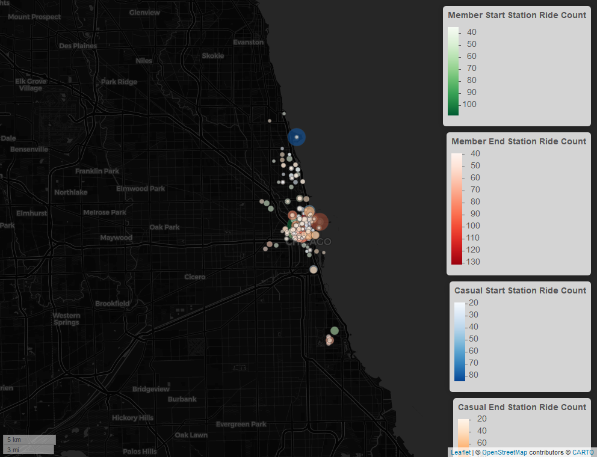

```r
viz_peak_fri_am <-
  mapview(stat_fri_am_mem_grouped_start[1:50, ],
          xcol = 'start_lng',
          ycol = 'start_lat',
          cex = 'ride_count',
          alpha = 0.5,
          grid = F,
          crs = 4269,
          legend = T,
          layer.name = 'Member Start Station Ride Count',
          zcol = 'ride_count',
          col.regions = brewer.pal(n = 8, name = 'Greens')
  )+
  mapview(stat_fri_am_mem_grouped_end[1:50, ],
          xcol = 'end_lng',
          ycol = 'end_lat',
          cex = 'ride_count',
          alpha = 0.5,
          grid = F,
          crs = 4269,
          legend = T,
          layer.name = 'Member End Station Ride Count',
          zcol = 'ride_count',
          col.regions = brewer.pal(n = 8, name = 'Reds')
  ) +
  mapview(stat_fri_am_cas_grouped_start[1:50, ],
          xcol = 'start_lng',
          ycol = 'start_lat',
          cex = 'ride_count',
          alpha = 0.5,
          grid = F,
          crs = 4269,
          legend = T,
          col.regions = brewer.pal(n = 8, name = 'Blues'),
          layer.name = 'Casual Start Station Ride Count',
          zcol = 'ride_count'
  ) +
  mapview(stat_fri_am_cas_grouped_end[1:50, ],
          xcol = 'end_lng',
          ycol = 'end_lat',
          cex = 'ride_count',
          alpha = 0.5,
          grid = F,
          crs = 4269,
          legend = T,
          col.regions = brewer.pal(n = 8, name = 'Oranges'),
          layer.name = 'Casual End Station Ride Count',
          zcol = 'ride_count'
  )
```

## **10.8c Peak Season Friday AM Commutes**

## **Lakeside Popularity**

#### Casual riders continue to show lots of activity around Cyclistic’s three main lakeside stations: Streeter Dr and Grand Ave, Montrose Harbor, and Michigan Ave & Oak Street.

## **Start Station Clustering**

#### We see two clusters of start stations popular amongst member and casual riders: First, between the residential neighborhoods of Lake View and Lincoln Park, and Second around the Near North Side downtown area.

#### Members also cluster start stations west of the Loop neighborhood near the Ogilive Transportation Center and some light clustering south of the Loop.

#### Casual riders also cluster start stations near the Loop, however we see more activity at the Loop’s northern and eastern borders.

## **End Station Clustering**

#### A review of end station activity shows a very pronounced cluster of members and casual riders ending their trips within the Loop and Near North Side neighborhoods. Likely indicating business commuters.

## **Transit Hub Activity**

#### Although we do see some overlapping member/casual activity near the Ogilvie Transportation Center and Millennium Station, El stations see less activity than the Thursday PM window, with only the Clark/Division, Chicago, and Fullerton stations seeing member/casual overlap.

#### While it is not directly adjacent to a transit hub, the Kingsbury St & Kinzie St station is within short walking distance of the Ogilive Transportation Center and appears popular with both casual and member riders. This station may see high traffic due to stations closer to the OTC running out of bikes to rent.

## **Interpretation**

#### While we see less indications of multimodal commuting, the natural flow of bikes from Lake View/Lincoln Park towards the loop and the large number of casual trips started just north of the Loop indicate a great opportunity to expand casual AM ridership.

#### Since a ride from Lake View/Lincoln Park into the city center is rather long, providing additional electric bikes along North Clark Street might entice additional casual riders to use the system.

## **10.8d Friday PM Commutes**

```r
#### Friday PM peak filter
stations_peak_friday_pm <- trips_w_stations %>%
  filter(weekday == "Friday") %>%
  filter(week >= 24 & week <= 27) %>%
  filter(start_hour >= 16 & start_hour <= 19)

stations_peak_friday_pm_cas <- stations_peak_friday_pm %>%
  filter(customer_type == 'casual')

stations_peak_friday_pm_mem <- stations_peak_friday_pm %>%
  filter(customer_type == 'member')
```

```r
## Friday pm member start station
stat_fri_pm_mem_grouped_start <- stations_peak_friday_pm_mem %>%
  group_by(start_station_name) %>%
  summarize(ride_count = n(), start_lng, start_lat,
            mean_trip_duration = mean(trip_length)) %>%
  arrange(desc(ride_count)) %>%
  distinct(start_station_name, .keep_all = TRUE)

## Friday pm member end station
stat_fri_pm_mem_grouped_end <- stations_peak_friday_pm_mem %>%
  group_by(end_station_name) %>%
  summarize(ride_count = n(), end_lng, end_lat,
            mean_trip_duration = mean(trip_length)) %>%
  arrange(desc(ride_count)) %>%
  distinct(end_station_name, .keep_all = TRUE)

## Friday pm casual start station for viz
stat_fri_pm_cas_grouped_start <- stations_peak_friday_pm_cas %>%
  group_by(start_station_name) %>%
  summarize(ride_count = n(), start_lng, start_lat,
            mean_trip_duration = mean(trip_length)) %>%
  arrange(desc(ride_count)) %>%
  distinct(start_station_name, .keep_all = TRUE)

## Friday pm casual end station for viz
stat_fri_pm_cas_grouped_end <- stations_peak_friday_pm_cas %>%
  group_by(end_station_name) %>%
  summarize(ride_count = n(), end_lng, end_lat,
            mean_trip_duration = mean(trip_length)) %>%
  arrange(desc(ride_count)) %>%
  distinct(end_station_name, .keep_all = TRUE)
```

#### Friday PM Visualization

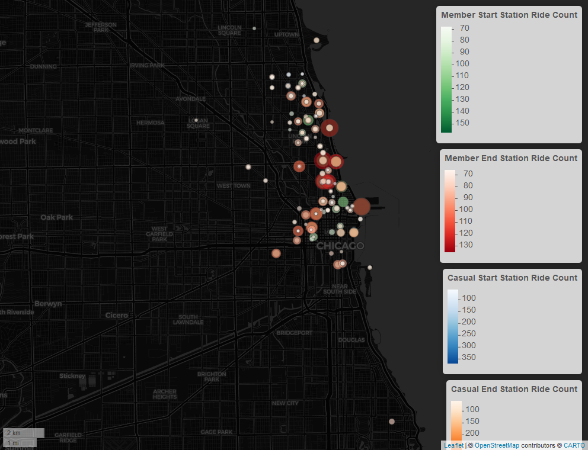

```r
## Viz
viz_peak_fri_pm <-
  mapview(stat_fri_pm_mem_grouped_start[1:50, ],
          xcol = 'start_lng',
          ycol = 'start_lat',
          cex = 'ride_count',
          alpha = 0.5,
          grid = F,
          crs = 4269,
          legend = T,
          layer.name = 'Member Start Station Ride Count',
          zcol = 'ride_count',
          col.regions = brewer.pal(n = 8, name = 'Greens')
  )+
  mapview(stat_fri_pm_mem_grouped_end[1:50, ],
          xcol = 'end_lng',
          ycol = 'end_lat',
          cex = 'ride_count',
          alpha = 0.5,
          grid = F,
          crs = 4269,
          legend = T,
          layer.name = 'Member End Station Ride Count',
          zcol = 'ride_count',
          col.regions = brewer.pal(n = 8, name = 'Reds')
  ) +
  mapview(stat_fri_pm_cas_grouped_start[1:50, ],
          xcol = 'start_lng',
          ycol = 'start_lat',
          cex = 'ride_count',
          alpha = 0.5,
          grid = F,
          crs = 4269,
          legend = T,
          col.regions = brewer.pal(n = 8, name = 'Blues'),
          layer.name = 'Casual Start Station Ride Count',
          zcol = 'ride_count'
  ) +
  mapview(stat_fri_pm_cas_grouped_end[1:50, ],
          xcol = 'end_lng',
          ycol = 'end_lat',
          cex = 'ride_count',
          alpha = 0.5,
          grid = F,
          crs = 4269,
          legend = T,
          col.regions = brewer.pal(n = 8, name = 'Oranges'),
          layer.name = 'Casual End Station Ride Count',
          zcol = 'ride_count'
  )
```

## **10.8d Peak Season Friday PM Commutes**

## **Thursday PM/Friday PM Similarities**

#### We see nearly identical behavior from member and casual riders when comparing Friday and Thursday PM rush hour periods. Although ride counts vary slightly from station to station and change their overall ranking, we see an almost identical list of popular stations amongst start and end stations for casual and member riders.

## **Interpretation**

#### The similarity between Thursday and Friday pm rush hour activity bodes extremely well, as it means we are working with predictable patterns of behavior from both cohorts of customers. Signing up for a Cyclistic subscription only makes sense if a customer uses the system frequently and bikes are easily available. Because customer behavior appears consistent from weeknight to weeknight, it should be easy to accomodate this need for reliability by restocking popular stations during the middle of the day.

## **10.8e Casual Behavior during Thursday/Friday AM Commutes By Hour**

#### In light of the notable increase in trip duration from 9am to 10:59am found in 10.7e, I think it is important to visualize this behavior by hour. Below is a visualization of casual rides by start hour. Use the layer selection to observe how casual behavior changes with time.

[figure not shown]

```r
## Hourly filter
stations_peak_thurs_fri_7_8 <- trips_w_stations %>%
  filter(customer_type == "casual") %>%
  filter(weekday == "Friday" |
           weekday == "Thursday") %>%
  filter(start_hour == 7 |
           start_hour == 8)


stations_peak_thurs_fri_9_10 <- trips_w_stations %>%
  filter(customer_type == "casual") %>%
  filter(weekday == "Friday" |
         weekday == "Thursday") %>%
  filter(start_hour == 9 |
           start_hour == 10)

## 7-8 start station
stat_7_8_start <- stations_peak_thurs_fri_7_8 %>%
  group_by(start_station_name) %>%
  summarize(ride_count = n(), start_lng, start_lat,
            mean_trip_duration = mean(trip_length)) %>%
  arrange(desc(ride_count)) %>%
  distinct(start_station_name, .keep_all = TRUE)

## 7-8 end station
stat_7_8_end <- stations_peak_thurs_fri_7_8 %>%
  group_by(end_station_name) %>%
  summarize(ride_count = n(), end_lng, end_lat,
            mean_trip_duration = mean(trip_length)) %>%
  arrange(desc(ride_count)) %>%
  distinct(end_station_name, .keep_all = TRUE)

## 9-10 start
stat_9_10_start <- stations_peak_thurs_fri_9_10 %>%
  group_by(start_station_name) %>%
  summarize(ride_count = n(), start_lng, start_lat,
            mean_trip_duration = mean(trip_length)) %>%
  arrange(desc(ride_count)) %>%
  distinct(start_station_name, .keep_all = TRUE)

## 9-10 end
stat_9_10_end <- stations_peak_thurs_fri_9_10 %>%
  group_by(end_station_name) %>%
  summarize(ride_count = n(), end_lng, end_lat,
            mean_trip_duration = mean(trip_length)) %>%
  arrange(desc(ride_count)) %>%
  distinct(end_station_name, .keep_all = TRUE)

viz_thurs_fri_am <-
  mapview(stat_7_8_start[1:50, ],
          xcol = 'start_lng',
          ycol = 'start_lat',
          cex = 'ride_count',
          alpha = 0.5,
          grid = F,
          crs = 4269,
          legend = T,
          layer.name = '7-8 Casual Start Station Ride Count',
          zcol = 'ride_count',
          col.regions = brewer.pal(n = 8, name = 'Greens')
  )+
  mapview(stat_7_8_end[1:50, ],
          xcol = 'end_lng',
          ycol = 'end_lat',
          cex = 'ride_count',
          alpha = 0.5,
          grid = F,
          crs = 4269,
          legend = T,
          layer.name = '7-8 Casual End Station Ride Count',
          zcol = 'ride_count',
          col.regions = brewer.pal(n = 8, name = 'Reds')
  ) +
  mapview(stat_9_10_start[1:50, ],
          xcol = 'start_lng',
          ycol = 'start_lat',
          cex = 'ride_count',
          alpha = 0.5,
          grid = F,
          crs = 4269,
          legend = T,
          col.regions = brewer.pal(n = 8, name = 'Blues'),
          layer.name = '9-10 Casual Start Station Ride Count',
          zcol = 'ride_count'
  ) +
  mapview(stat_9_10_end[1:50, ],
          xcol = 'end_lng',
          ycol = 'end_lat',
          cex = 'ride_count',
          alpha = 0.5,
          grid = F,
          crs = 4269,
          legend = T,
          col.regions = brewer.pal(n = 8, name = 'Oranges'),
          layer.name = '9-10 Casual End Station Ride Count',
          zcol = 'ride_count'
  )
```

## **10.8e Casual Behavior during Thursday/Friday AM Commutes By Hour**

#### The above visualization clarifies our findings in 10.7e.

#### Casual rides initiated from 7am - 8:59am have start stations clustered in neighborhoods around the Loop (Near North Side, Greektown, and Printer’s Row), as well as along the North Wells and North Lincoln Avenue traffic corridors. El stations and transit hubs appear to be at the center of these clusters, indicating multimodal commuting.

#### Casual rides initiated at this time have end stations clustered heavily in the Loop business district and Transit hubs just east and west of the neighborhood (Chicaco Union Station, Ogilvie and Transportation Center).

#### Casual rides initiated from 9am to 10:59am have far more dispersed start stations, with lakeside stations and stations along the Miracle Mile showing far more popularity than earlier in the day. While some popular start stations exist in the Near North Side, just north of the loop, these stations are far less popular than from 7am - 8:59am.

#### While there are still 9 popular end stations within the loop during this time, they represent a much lower percentage of overal rides than we see earlier in the day. Instead, we see lakeside stations and those along Miracle Mile resume their top positions.

## **Interpretation**

#### A detailed review of casual rider behavior on workday mornings demonstrates that commuter activity is taking place, albeit during a smaller window of time than member riders. We also now have clarification on the jump in casual trip duration after 9am, which does appear to reflect a move from shorter, destination-focused riding to recreational riding more similar to what we see during peak season weekends.

## **11 Key Findings**

#### After a thorough review of annual ride data, we now have answers to the questions posed at the beginning of this analysis. The following section outlines key takeaways for Cyclistic’s digital marketing team and is followed by data-backed recommendations for their new campaign.

## **Comparing Casual and Member Riders**

#### The average casual rider is a less experienced cyclist who seeks comfortable, longer, more leisurely rides.

#### The average member rider is a more experienced cyclist who demonstrates a higher tolerance for poor weather and destination-focused rides.

#### Casual riders demonstrate a higher demand for electric bikes (10.5b) and benefit significantly from the electric assist, with electric bikes shortening their average ride by 25.58% (10.5c). If weather conditions are optimal (peak season), they are somewhat more willing to use classic bikes (10.5e). Casual riders are significantly slower than member riders when moving from start to end stations (10.5g).

#### Member riders show less demand for electric bikes (10.5b) and see a smaller decrease (8.41%) in trip duration when riding electric bikes (10.5c), suggesting they are somewhat more adept at selecting bike types based on their planned journey.

#### Based on trip durations and distances traveled, members travel 50.93% faster than casual riders when both are using classic bikes. Members travel 57.47% faster than casual riders when both are using electric bikes (10.5g).

## **Peak Season and Weather**

#### During peak season, casual riders will initiate 6.71% more rides during the 7am - 10:59am window, 9.49% more rides from 11am to 3:59pm, and 7.53% more rides during the 4pm - 7:59pm window (10.6d).

#### During the peak season AM window, casual riders are most active Thursday, Friday, and Monday mornings (10.6e).

#### During the peak season PM window, casual riders are most active Thursday, Friday, and Wednesday nights (10.6e).

## **Station-to-Station Behavior During Peak Season**

## **Weekends (10.8a)**

#### Both member and casual riders take the majority of trips along the Chicago waterfront, with elevated casual activity along the Magnificent mile and South/North Michigan Avenue, North Wells Street, and North Clark Street traffic corridors.

#### Members show more activity west of the Chicago River when compared to casual riders, who only frequented stations around Logan Square, Wicker Park, and a major traffic intersection at West Division and Milwaukee Ave.

## **Thursday/Friday Casual Rides By Hour (10.8e)**

#### There is a clear desire for casual riders to use Cyclistic for commuting purposes from 7am to 8:59am, with the North Wells and North Lincoln Avenue traffic corridors being popular start station locations, as well as the Greektown and Near North Side neighborhoods. This indicates that earlier in the morning, casual riders are open to both door-to-door (in the case of the traffic corridors) and multimodal (in the case of Near North Side and Greektown) commuting. Rides initiated at this time have a much higher frequency of end stations within the Loop neighborhood.

#### After 9am, we see behavior much more in line with weekend activity, as lakeside stations and the Miracle Mile neighborhood see signficant increases in activity.

## **11 Recommendations**

## **1 - Timing**

#### In order to reach the most casual customers when they are most engaged with the Cyclistic system, the digital marketing team should closely monitor weather forecasts to determine when to activate their campaign.

#### The digital marketing team should prepare to activate their campaign during the first weeks that the following conditions will be consistently met:

#### 1) Average weekly temperatures reach about 80 degrees.

#### 2) Average weekly Humidity is below 50%.

#### 3) Weekly rainfall is expected to sit below 0.5 inches.

#### *When monitoring weather to anticipate peak casual ridership, special attention should be paid when average weekly temperature is expected to jump 10+ degrees and humidity is expected to drop by 10% or more.*

## **2 - Strategic Electric Bike Placement**

#### Casual customers have a strong preference for electric bikes, which should be manually shifted to stations where casual riders frequently initiate destination-focused trips, rather than recreational lake-side rides.

#### Weekend: Electric bikes should be shuttled from lakeside stations to those along North Lincoln Ave, North Clarke St, North Wells Street, and North/South Michigan Avenues, as well as near Logan Square and Wicker Park. This would promote more destination-focused travel than the leisure-focused rides along the lake.

#### Workday AM Commute Window: Electric bikes should be positioned along Northern traffic corridors from Lakeview through Lincoln Park and the Near North Side. Additionally, electric bikes should be placed near El stations and Transportation Centers, with a focus on those that ring the Loop to the north (Near North Side), west (Greektown), and south (Printer’s Row).

#### These rebalances must happen before 7am every workday to achieve maximum effect.

#### Stations within one block of the following El Stations are top priority for electric rebalancing: Belmont, Fullerton, North/Clybourn, Clark/Division, and Grand, as well as the Oglvie and Milennium transportation centers.

#### Workday PM Commute Window: Electric Bikes should be positioned along the same traffic coridors and El stations as outlined during the AM commute window, excluding Printer’s Row and Greektown neighborhoods.

## **3 - Encourage Repeat Use**

#### Casual customers who use a bike during the weekday AM or PM commute window should be offered a credit for a free ride during the same period the following day and/or the following commute period. If customers do not use the initial credit, they should be offered a second credit for a ride during the same commute window one week after their initial ride.

#### By encouraging repeat use, casual members will become more familiar with the system and receive additional opportunities to understand how they system can be applied to their daily routine, creating an easy argument for membership.

## **4 - Partner with Cycling Advocacy Groups**

#### Based on rider behavior, casual riders are generally not experienced cyclists. As a result, Cyclistic should partner with existing transportation and cycling advocacy groups that already have experience introducing the concept of bike commuting to novice riders.

#### This mutually beneficial partnership would allow Cyclistic to use the advocacy groups existing outreach network and publicity aparatus. Meanwhile, advocacy groups would have an easier time increasing urban bicycle use because the Cyclistic system removes the need to own a personal bicycle.

## **5 - Focus Messaging on Affordability and Ease-of-Use for Electric Bikes**

#### Most bike share programs charge more for electric bikes, and casual riders have a preference for this option. After completing an electric ride as a non-subscriber, casual riders should be sent a follow-up message showing A) The amoung of money they could save on the ride through membership and B) A comparison of their station-to-station trip duration versus the average station-to-station time on a classic bike.